# Assignment n.4

One-way ANOVA and interaction effects

2025-03-21

### **The `survival time to poison` dataset**

The `surtime.txt` file contains the *survival time to poison* data set. The data give the survival times (in 10 hour units) in a 3 x 4 factorial experiment, the factors being (a) three poisons and (b) four treatments. Each combination of the two factors is used for four animals, the allocation to animals being completely randomized.

##### 1. **Load the *surtime* data and make sure that the variables `Poison` and `Treatment` are properly defined to have class *factor*.**

```r
surtime <- read.table("surtime.txt", head=TRUE)
is.factor(surtime$Poison)
```

```
## [1] FALSE
```

```r
is.factor(surtime$Treatment)
```

```
## [1] FALSE
```

```r
surtime$Poison    <- as.factor(surtime$Poison)
surtime$Treatment <- as.factor(surtime$Treatment)
```

##### 2. **Apply one-way Analysis of Variance (ANOVA) to compare the mean survival times of the tree poisons. Include a Bartlett test to check the assumption of equal variances and a post-hoc analysis based on Tukey HSD (honestly significant difference) method. Comment the results you obtain.**

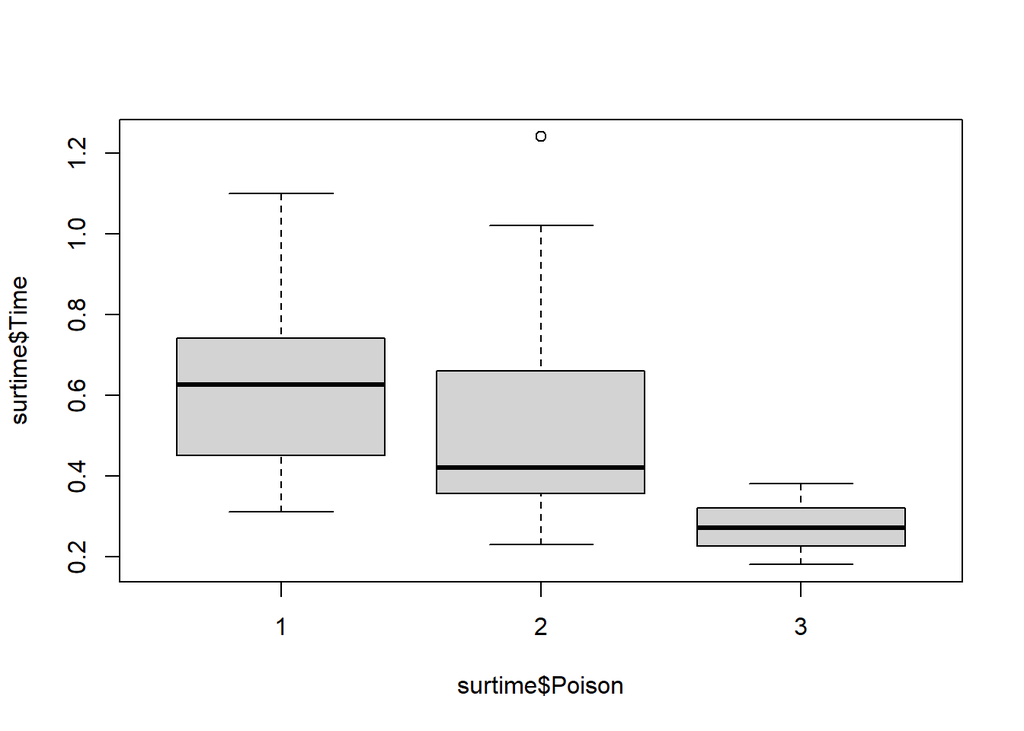

```r
boxplot(surtime$Time~ surtime$Poison)
```

```r
# test for equal variances
bartlett.test(Time~ Poison, data=surtime)
```

```
##
##  Bartlett test of homogeneity of variances
##
## data:  Time by Poison
## Bartlett's K-squared = 25.88, df = 2, p-value = 2.4e-06
```

```r
# ANOVA table
aov.poison <- aov(Time~ Poison, data=surtime)
summary(aov.poison)
```

```
##             Df Sum Sq Mean Sq F value   Pr(>F)
## Poison       2  1.033  0.5165   11.79 7.66e-05 ***
## Residuals   45  1.972  0.0438
## ---
## Signif. codes:  0 '***' 0.001 '**' 0.01 '*' 0.05 '.' 0.1 ' ' 1
```

```r
# Tukey post hoc analysis
tukey.poison <- TukeyHSD(aov.poison)
tukey.poison
```

```
##   Tukey multiple comparisons of means
##     95% family-wise confidence level
##
## Fit: aov(formula = Time ~ Poison, data = surtime)
##
## $Poison
##          diff        lwr         upr     p adj
## 2-1 -0.073125 -0.2525046  0.10625464 0.5881654
## 3-1 -0.341250 -0.5206296 -0.16187036 0.0000971
## 3-2 -0.268125 -0.4475046 -0.08874536 0.0020924
```

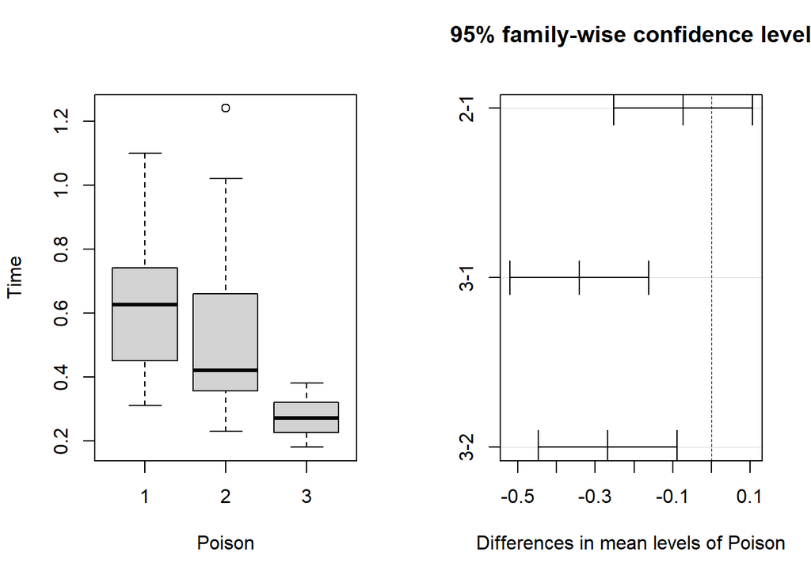

```r
par(mfrow=c(1, 2))
plot(Time~ Poison, data=surtime)
plot(tukey.poison)
```

```r
par(mfrow=c(1,1))
```

Conclusions:

1. According to the Bartlett test we cannot accept the assumption of equal variances, and thus the results of the ANOVA analysis are not fully reliable.
2. The ANOVA table shows that the hypothesis that the mean survival times of the three poisons are not equal is highly significant, and should thus be accepted.
3. The Tukey post hoc analysis gives insight into the three pairwise mean comparisons, thereby showing that the difference among poisons is mainly due to poison 3 whose mean survival time seems to be significantly shorter than both that of poison 1 and poison 2.

##### 3. **Show how the ANOVA test that in the previous point is computed with the `aov()` function can also be computed with the `lm()` function.**

```r
lmfit <- lm(Time~ Poison, data=surtime)
summary(lmfit)
```

```
##
## Call:
## lm(formula = Time ~ Poison, data = surtime)
##
## Residuals:
##      Min       1Q   Median       3Q      Max
## -0.31438 -0.15922 -0.03125  0.08594  0.69562
##
## Coefficients:
##             Estimate Std. Error t value Pr(>|t|)
## (Intercept)  0.61750    0.05234  11.799 2.28e-15 ***
## Poison2     -0.07313    0.07401  -0.988    0.328
## Poison3     -0.34125    0.07401  -4.611 3.32e-05 ***
## ---
## Signif. codes:  0 '***' 0.001 '**' 0.01 '*' 0.05 '.' 0.1 ' ' 1
##
## Residual standard error: 0.2093 on 45 degrees of freedom
## Multiple R-squared:  0.3438, Adjusted R-squared:  0.3146
## F-statistic: 11.79 on 2 and 45 DF,  p-value: 7.656e-05
```

The ANOVA test can be found in the last row of the output. A more complete representation of the ANOVA table can then obtained as follows.

```r
lmfit.null <- lm(Time~+1, data=surtime)
anova(lmfit.null, lmfit)
```

```
## Analysis of Variance Table
##
## Model 1: Time ~ +1
## Model 2: Time ~ Poison
##   Res.Df    RSS Df Sum of Sq      F    Pr(>F)
## 1     47 3.0051
## 2     45 1.9721  2     1.033 11.786 7.656e-05 ***
## ---
## Signif. codes:  0 '***' 0.001 '**' 0.01 '*' 0.05 '.' 0.1 ' ' 1
```

##### 4. **Apply one-way Analysis of Variance (ANOVA) to compare the mean survival times of the four treatments. Include a Bartlett test to check the assumption of equal variances and a post-hoc analysis based on Tukey HSD (honestly significant difference) method. Comment the results you obtain.**

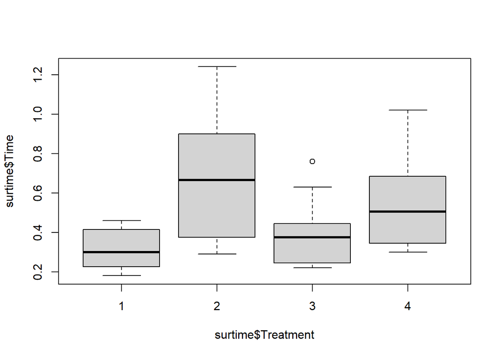

```r
boxplot(surtime$Time~ surtime$Treatment)
```

```r
# test for equal variances
bartlett.test(Time~ Treatment, data=surtime)
```

```
##
##  Bartlett test of homogeneity of variances
##
## data:  Time by Treatment
## Bartlett's K-squared = 13.211, df = 3, p-value = 0.004202
```

```r
# ANOVA table
aov.treatment <- aov(Time~ Treatment, data=surtime)
summary(aov.treatment)
```

```
##             Df Sum Sq Mean Sq F value   Pr(>F)
## Treatment    3 0.9212 0.30707   6.484 0.000992 ***
## Residuals   44 2.0839 0.04736
## ---
## Signif. codes:  0 '***' 0.001 '**' 0.01 '*' 0.05 '.' 0.1 ' ' 1
```

```r
# Tukey post hoc analysis
tukey.treatment <- TukeyHSD(aov.treatment)
tukey.treatment
```

```
##   Tukey multiple comparisons of means
##     95% family-wise confidence level
##
## Fit: aov(formula = Time ~ Treatment, data = surtime)
##
## $Treatment
##            diff         lwr         upr     p adj
## 2-1  0.36250000  0.12528287  0.59971713 0.0010358
## 3-1  0.07833333 -0.15888380  0.31555047 0.8143113
## 4-1  0.22000000 -0.01721713  0.45721713 0.0778376
## 3-2 -0.28416667 -0.52138380 -0.04694953 0.0131752
## 4-2 -0.14250000 -0.37971713  0.09471713 0.3869986
## 4-3  0.14166667 -0.09555047  0.37888380 0.3921830
```

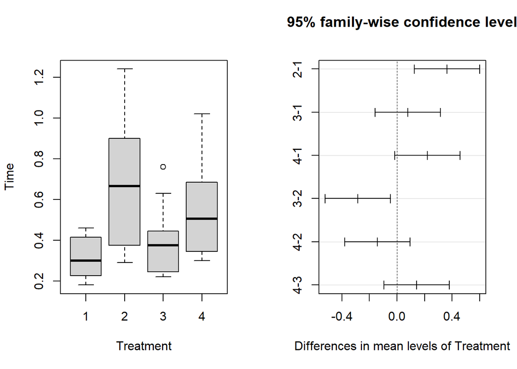

```r
par(mfrow=c(1, 2))
plot(Time~ Treatment, data=surtime)
plot(tukey.treatment)
```

```r
par(mfrow=c(1,1))
```

Conclusions:

1. According to the Bartlett test we cannot accept the assumption of equal variances, and thus the results of the ANOVA analysis are not fully reliable.
2. The ANOVA table shows that the hypothesis that the mean survival times of the four treatments are not equal is highly significant, and should thus be accepted.
3. The Tukey post hoc analysis gives insight into the six pairwise mean comparisons, thereby showing that the difference among treatments is mainly due to treatment 2 whose mean survival time seems to be significantly longer than both that of treatments 1 and poison 3.

##### 5. **Fit the linear regression model of `Time` on `Poison` and `Treatment` including the interaction effects between the two explanatory variables. Can you conclude that `Poison` and `Treatment` significantly interact?**

```r
lmfit <- lm(Time~ Poison*Treatment, data=surtime)
summary(lmfit)
```

```
##
## Call:
## lm(formula = Time ~ Poison * Treatment, data = surtime)
##
## Residuals:
##      Min       1Q   Median       3Q      Max
## -0.32500 -0.04875  0.00500  0.04312  0.42500
##
## Coefficients:
##                    Estimate Std. Error t value Pr(>|t|)
## (Intercept)         0.41250    0.07457   5.532 2.94e-06 ***
## Poison2            -0.09250    0.10546  -0.877   0.3862
## Poison3            -0.20250    0.10546  -1.920   0.0628 .
## Treatment2          0.46750    0.10546   4.433 8.37e-05 ***
## Treatment3          0.15500    0.10546   1.470   0.1503
## Treatment4          0.19750    0.10546   1.873   0.0692 .
## Poison2:Treatment2  0.02750    0.14914   0.184   0.8547
## Poison3:Treatment2 -0.34250    0.14914  -2.297   0.0276 *
## Poison2:Treatment3 -0.10000    0.14914  -0.671   0.5068
## Poison3:Treatment3 -0.13000    0.14914  -0.872   0.3892
## Poison2:Treatment4  0.15000    0.14914   1.006   0.3212
## Poison3:Treatment4 -0.08250    0.14914  -0.553   0.5836
## ---
## Signif. codes:  0 '***' 0.001 '**' 0.01 '*' 0.05 '.' 0.1 ' ' 1
##
## Residual standard error: 0.1491 on 36 degrees of freedom
## Multiple R-squared:  0.7335, Adjusted R-squared:  0.6521
## F-statistic:  9.01 on 11 and 36 DF,  p-value: 1.986e-07
```

We can see that the interaction effect between the two variables is represented by 6 interaction parameters and the interaction coefficient corresponding to the `Poison3:Treatment2` seems to be significantly different to zero. However, this could be due to a first type error: we are considering 6 test procedures and the overall significance level of this procedure is not known and, possibly, much greater than the desired 0.05 significance level. Hence, we carry out a single F-test for the null hypothesis that all the 6 interaction coefficients are equal to zero.

```r
lmfit.null <- lm(Time~ Poison+Treatment, data=surtime)
anova(lmfit.null, lmfit)
```

```
## Analysis of Variance Table
##
## Model 1: Time ~ Poison + Treatment
## Model 2: Time ~ Poison * Treatment
##   Res.Df     RSS Df Sum of Sq      F Pr(>F)
## 1     42 1.05086
## 2     36 0.80073  6   0.25014 1.8743 0.1123
```

The latter shows that, at the 0.05 significance level, there is not empirical evidence that `Poison` and `Treatment` significantly interact.

##### 6. **Consider again the linear regression model of `Time` on `Poison` and `Treatment` including the interaction effects, and carry out a residual analysis. Can you conclude that the assumption of homoscedasticity is satisfied? Try the following three transformations of the response: (i) `log(Time)`, (ii) `sqrt(Time)` and (iii) `1/Time` and comment the results you obtain.**

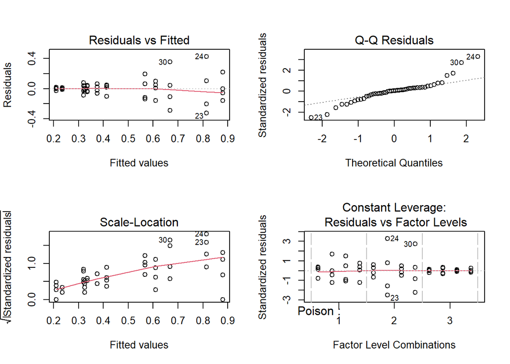

```r
lmfit <- lm(Time~ Poison*Treatment, data=surtime)

par(mfrow=c(2,2))
plot(lmfit)
```

```r
par(mfrow=c(1,1))
```

The scale-location plot shows that the residual variance seems to increase as survival time increases.

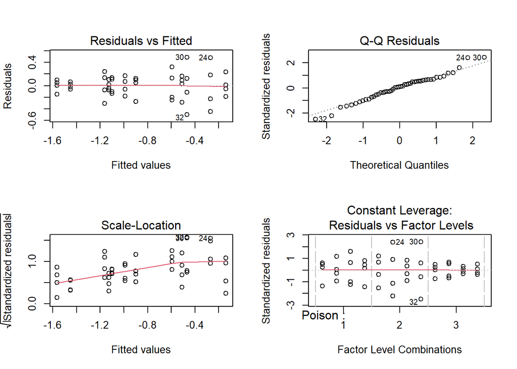

```r
lmfit <- lm(log(Time)~ Poison*Treatment, data=surtime)

par(mfrow=c(2,2))
plot(lmfit)
```

```r
par(mfrow=c(1,1))
```

Also after the log-trasformation of the respose the error terms don’t look homoscedastic.

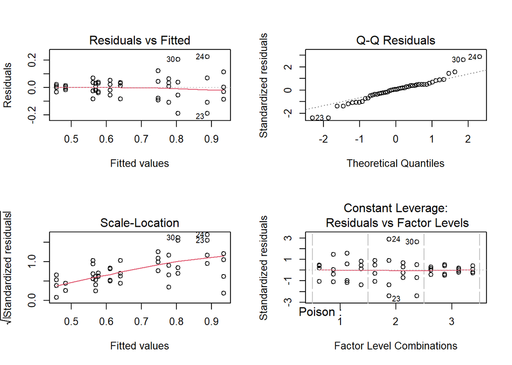

```r
lmfit <- lm(sqrt(Time)~ Poison*Treatment, data=surtime)

par(mfrow=c(2,2))
plot(lmfit)
```

```r
par(mfrow=c(1,1))
```

Similarly to the log-trasformation, also the square root does not seem to solve the problem.

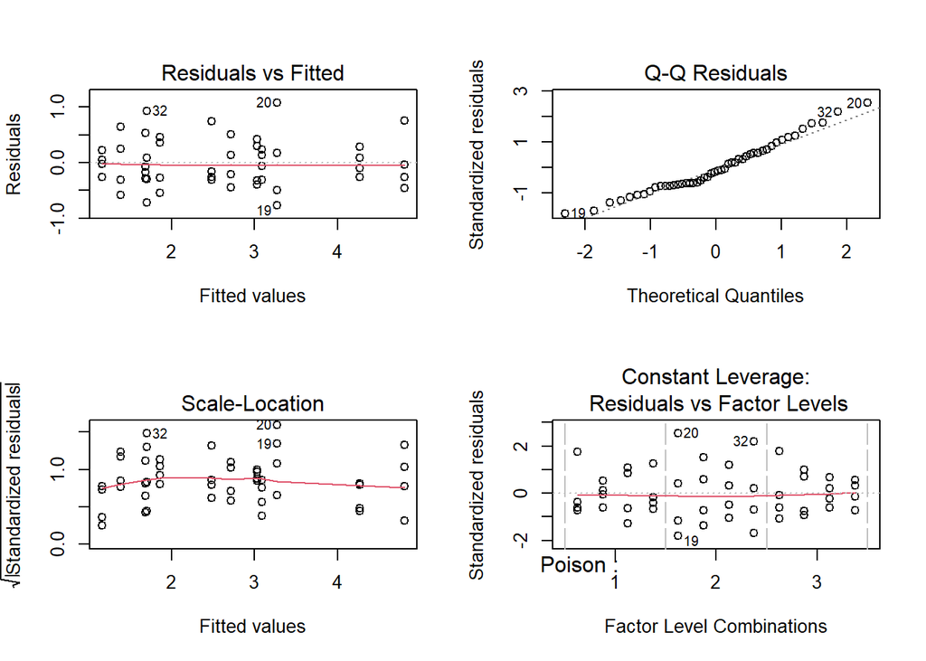

```r
lmfit <- lm((1/Time)~ Poison*Treatment, data=surtime)

par(mfrow=c(2,2))
plot(lmfit)
```

```r
par(mfrow=c(1,1))
```

Under the reciprocal transformation the scale-location plot shows the desired pattern.

We consider first the explanatory `Poison`,

```r
boxplot((1/Time)~ Poison, data=surtime)

# test for equal variances
bartlett.test((1/Time)~ Poison, data=surtime)
```

[output not shown]

```
##
##  Bartlett test of homogeneity of variances
##
## data:  (1/Time) by Poison
## Bartlett's K-squared = 3.1163, df = 2, p-value = 0.2105
```

```r
# ANOVA table
aov.poison <- aov((1/Time)~ Poison, data=surtime)
summary(aov.poison)
```

```
##             Df Sum Sq Mean Sq F value   Pr(>F)
## Poison       2  34.88  17.439   25.62 3.73e-08 ***
## Residuals   45  30.63   0.681
## ---
## Signif. codes:  0 '***' 0.001 '**' 0.01 '*' 0.05 '.' 0.1 ' ' 1
```

```r
# Tukey post hoc analysis
tukey.poison <- TukeyHSD(aov.poison)
tukey.poison
```

```
##   Tukey multiple comparisons of means
##     95% family-wise confidence level
##
## Fit: aov(formula = (1/Time) ~ Poison, data = surtime)
##
## $Poison
##          diff        lwr      upr     p adj
## 2-1 0.4686413 -0.2382823 1.175565 0.2533237
## 3-1 1.9964249  1.2895013 2.703349 0.0000001
## 3-2 1.5277837  0.8208601 2.234707 0.0000122
```

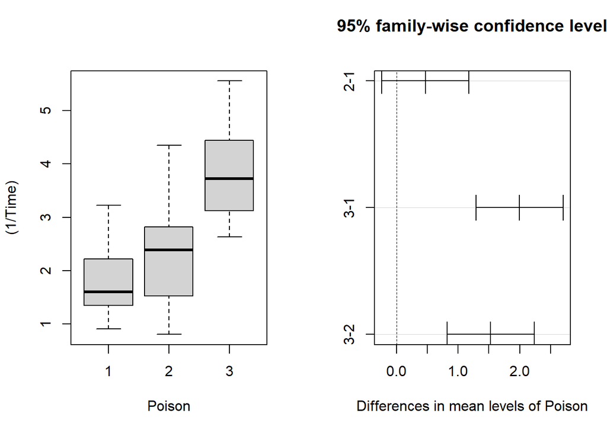

```r
par(mfrow=c(1, 2))
plot((1/Time)~ Poison, data=surtime)
plot(tukey.poison)
```

```r
par(mfrow=c(1,1))
```

Now the assumption of equal variances seems to be justified. Hence, the results we obtain are more reliable, and they agree with those of point 2 above.

We now turn to the the explanatory `Treatment`,

```r
boxplot((1/Time)~ Treatment, data=surtime)

# test for equal variances
bartlett.test((1/Time)~ Treatment, data=surtime)
```

[output not shown]

```
##
##  Bartlett test of homogeneity of variances
##
## data:  (1/Time) by Treatment
## Bartlett's K-squared = 1.5477, df = 3, p-value = 0.6713
```

```r
# ANOVA table
aov.treatment <- aov((1/Time)~ Treatment, data=surtime)
summary(aov.treatment)
```

```
##             Df Sum Sq Mean Sq F value  Pr(>F)
## Treatment    3  20.41   6.805    6.64 0.00085 ***
## Residuals   44  45.09   1.025
## ---
## Signif. codes:  0 '***' 0.001 '**' 0.01 '*' 0.05 '.' 0.1 ' ' 1
```

```r
# Tukey post hoc analysis
tukey.treatment <- TukeyHSD(aov.treatment)
tukey.treatment
```

```
##   Tukey multiple comparisons of means
##     95% family-wise confidence level
##
## Fit: aov(formula = (1/Time) ~ Treatment, data = surtime)
##
## $Treatment
##           diff         lwr        upr     p adj
## 2-1 -1.6574024 -2.76085841 -0.5539464 0.0012809
## 3-1 -0.5721354 -1.67559147  0.5313206 0.5156472
## 4-1 -1.3583383 -2.46179432 -0.2548823 0.0103775
## 3-2  1.0852669 -0.01818908  2.1887230 0.0554193
## 4-2  0.2990641 -0.80439193  1.4025201 0.8871316
## 4-3 -0.7862029 -1.88965888  0.3172532 0.2418871
```

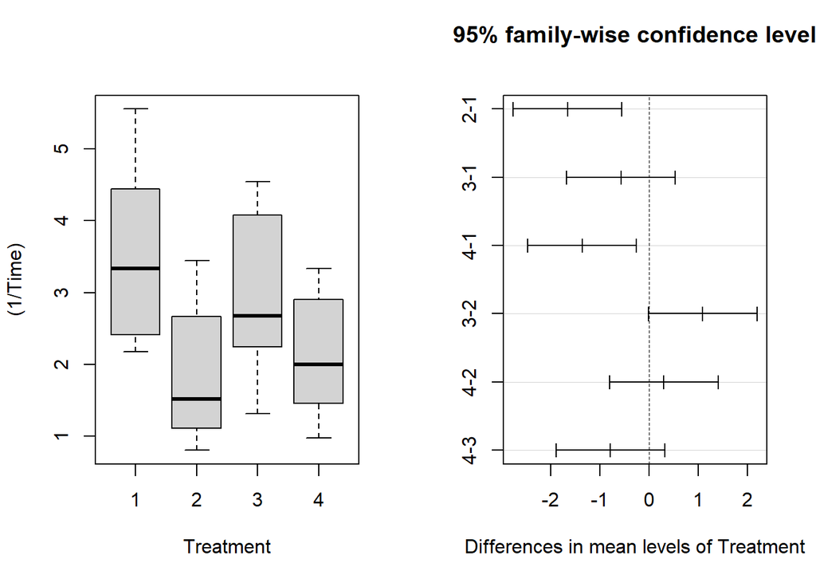

```r
par(mfrow=c(1, 2))
plot((1/Time)~ Treatment, data=surtime)
plot(tukey.treatment)
```

```r
par(mfrow=c(1,1))
```